# Statistical Inference Course Project (Part 1)

Annette Spithoven

3-11-2019

## 1. Overview

For the first part of the Statistical Inference Course Project the exponential distribution will be investigated and compared with the Central Limit Theorem.The mean of exponential distribution is 1/lambda and the standard deviation is also 1/lambda. Lambda is set to 0.2 for all of the simulations. The distribution of averages of 40 exponentials is investigated over a thousand simulations.

## 2. Simulations

```r
## setting seed to make simulations reproducable
set.seed(2019)

## setting predefined sample values
lambda <- 0.2
n_exponentials <- 40 ## number of exponentials
sim <- 1000 ## number of simulations
```

Using the predifined sample values (see the assignment explanation above) we generate 1000 simulations with 40 exponentials.

```r
simulations <- replicate(sim, rexp(n_exponentials,lambda))

## calculating the mean of the exponentials
mean_sim <- data.frame(Means = colMeans(simulations))
```

## Sample Mean versus Theoretical Mean

The plot below gives a graphical representation of the mean values of the simulation exponentials. The red line represents the sample mean (5.0387553), the blue line represents the theoretical mean (5).

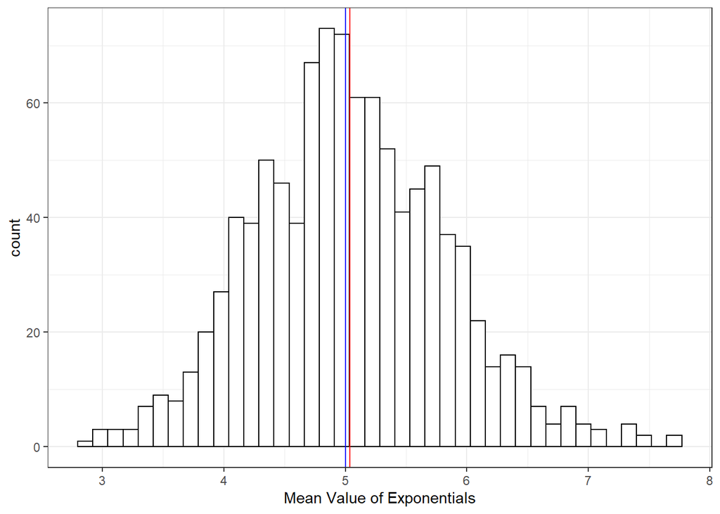

```r
## Calculating the sample mean
sample_mean <- mean(mean_sim$Means)
theoretical_mean <- 1/lambda

ggplot(mean_sim, aes(x = Means)) +
  geom_histogram(aes(y=..count..),
                 bins = 40,
                 color="black",
                 fill="white") +
  labs(main = "Means of 1000 Simulations with 40 Exponentials",
     x = "Mean Value of Exponentials") +
  ## add vertical line for sample mean
  geom_vline(xintercept = sample_mean,
             col = "red") +
  ## add vertical line for the theoretical mean
  geom_vline(xintercept= theoretical_mean,
             col = "blue" )+
  theme_bw()
```

There is slight difference between the simulation sample mean and the theoretical expected mean.

## Sample Variance versus Theoretical Variance

The theoretical and sample variance were calculated

```r
## Calculating the sample variance
sample_variance <- var(mean_sim$Means)
## Calculating the theoretical variance
theoretical_variance <- ((1/lambda)/sqrt(n_exponentials))^2

cbind(sample_variance, theoretical_variance)
```

```
##      sample_variance theoretical_variance
## [1,]       0.6253269                0.625
```

The difference between the two variances is small (-3.269268110^{-4}).

## Distribution

The plot below shows the density distribution for the sample as well as the theoretical distribution.

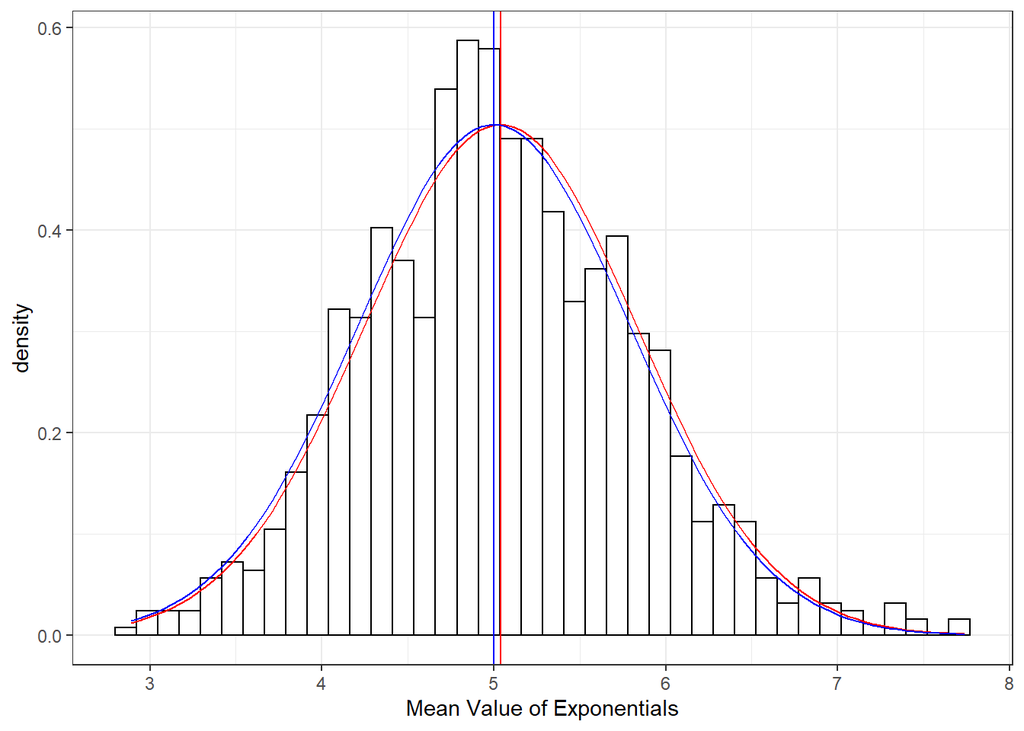

```r
ggplot(mean_sim, aes(x = Means)) +
  geom_histogram(aes(y=..density..),
                 bins = 40,
                 color="black",
                 fill="white") +
  labs(main = "Histogram of 1000 Simulations with 40 Exponentials",
     x = "Mean Value of Exponentials") +
  ## add sample distribution
  stat_function(fun = dnorm,
                args = list(mean = sample_mean,
                            sd = sqrt(sample_variance)),
                col = "red")+
  ## add vertical line for sample mean
  geom_vline(xintercept = sample_mean,
             col = "red") +
  ## add theoretical distribution
  stat_function(fun=dnorm,
                args=list( mean=theoretical_mean,
                           sd=sqrt(theoretical_variance)),
                color = "blue") +
  ## add vertical line for the theoretical mean
  geom_vline(xintercept= theoretical_mean,
             col = "blue" )+
  theme_bw()
```

As can be seen in the plot, the distributions are very close to each other.